# Exponential Distribution and Central Limit Theorem

Martin Connolly

June 21, 2015

# Overview

This report will investigate the exponential distribution in R and compare it to the Central Limit Theorem. This report will detail the investigation of the distribution of averages of 40 exponentials over 1000 simulations.

# Simulations

In this investigation we use the `rexp` function within R to generate an exponential sample distribution, The mean of the exponential distribution population is $\mu=1/\lambda$ and the standard deviation is $\sigma=1/\lambda$.

```r
library(ggplot2)
library(dplyr)
lambda <- 0.2
n <- 40 #sample size
simul_count <- 1000 #number of simulations
dist_mu <- 1 / lambda
dist_sigma <- 1 / lambda

set.seed(17) # set seed value for reproducability

# create empty data frame for simulation data
simul_data <- data.frame(matrix(NA, nrow = simul_count, ncol = n + 1))
names(simul_data)[n + 1] <- "sample_mean"

# generate 1000 random exponential distributions of sample size 40
# with each sample in a new row
for(i in 1:simul_count) {
        temp_data <- rexp(n, lambda)
        simul_data[i, ] <- c(temp_data, mean(temp_data))
}
```

# Sample Mean versus Theoretical mean

As stated the theoretical mean (mean of the population) is $\mu=1/\lambda$, as $\lambda=0.2$ then $\mu=5$

The mean of all the samples can be calculated as follows;

```r
mean_of_all_samples <- mean(simul_data$sample_mean)
mean_of_all_samples
```

```
## [1] 4.961683
```

So we can see that mean of the sample distributions 4.9616831 is very near the mean of the population 5. Below you can see a plot of the distribution of sample means, with the mean of all samples marked by a red dotted line and the population mean marked with a black dotted line.

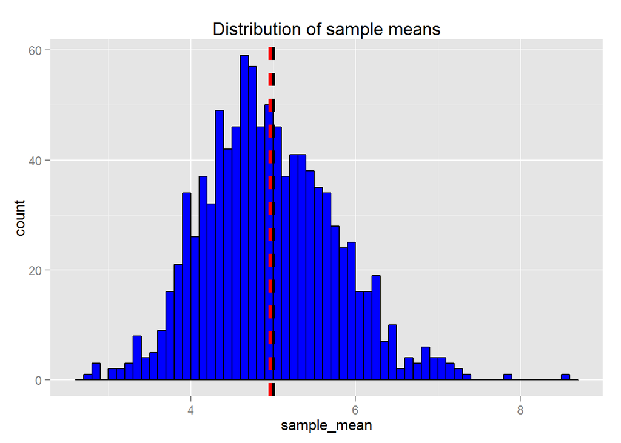

```r
ggplot(simul_data, aes(x=sample_mean)) +
        geom_histogram(binwidth = 0.1, colour = "black", fill = "blue") +
        geom_vline(xintercept = mean_of_all_samples, size = 1.3, colour = "red",
                linetype = "dashed", show_guide = TRUE) +
        geom_vline(xintercept = 1 / lambda, size = 1.3, colour = "black",
                linetype = "dashed", show_guide = TRUE) +
        ggtitle("Distribution of sample means")
```

# Sample Variance versus Theoretical Variance

The theoretical variance of the sample means is $\sigma^2/n$, which is 0.625. The actual variance of the sample means is as follows;

```r
sample_var <- var(simul_data$sample_mean)
sample_var
```

```
## [1] 0.6408254
```

So the difference between the theoretical and actual variance can be seen as

```r
(dist_sigma^2 / n) - sample_var
```

```
## [1] -0.01582538
```

# Distribution

If we look at the distribution of sample means below, we can quickly see that it’s approximately normal. The green line is the density function of the sample_mean distribution and the blue line is the normal distribution.

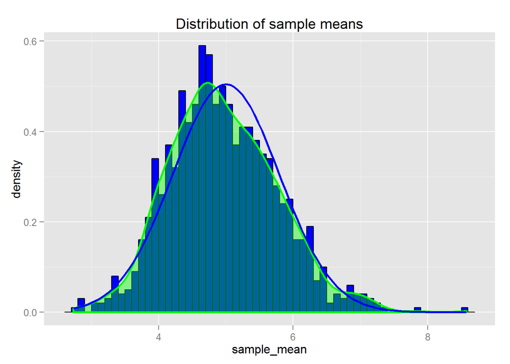

```r
ggplot(simul_data, aes(x=sample_mean)) +
        geom_histogram(binwidth = 0.1, colour = "black", fill = "blue",
                       aes(y=..density..)) +
        geom_density(colour = "green", fill = "green", alpha = 0.4, size = 1) +
        stat_function(fun = dnorm, args = list(mean = dist_mu, sd = sqrt(dist_sigma^2 / n)),
                      colour = "blue", size = 1) +
        ggtitle("Distribution of sample means")
```